# R with Regression and Visualization

Victoria Mosby

2022-12-07

## Prompt

Choose a different city from Vienna and make sure you have at least 100 observations after filtering. Create at least 3 models with at least 3 explanatory variables (check for transformation) and choose the best. Imagine you can build a new hotel in your city and can specify the feature values as you wish. Predict the price and estimate confidence and prediction intervals with a 90% significance level. Set the price of your hotel and argue, why is it your choice.

|  | Mean | SD | Min | Max | Median | P95 | N |
| --- | --- | --- | --- | --- | --- | --- | --- |
| price | 103.98 | 33.03 | 51.00 | 264.00 | 98.00 | 162.00 | 249 |
| lnprice | 4.60 | 0.29 | 3.93 | 5.58 | 4.58 | 5.09 | 249 |
| distance | 1.20 | 0.82 | 0.10 | 4.60 | 1.00 | 2.80 | 249 |
| stars | 3.59 | 0.49 | 3.00 | 4.00 | 4.00 | 4.00 | 249 |
| rating | 4.10 | 0.32 | 3.20 | 5.00 | 4.00 | 4.60 | 248 |

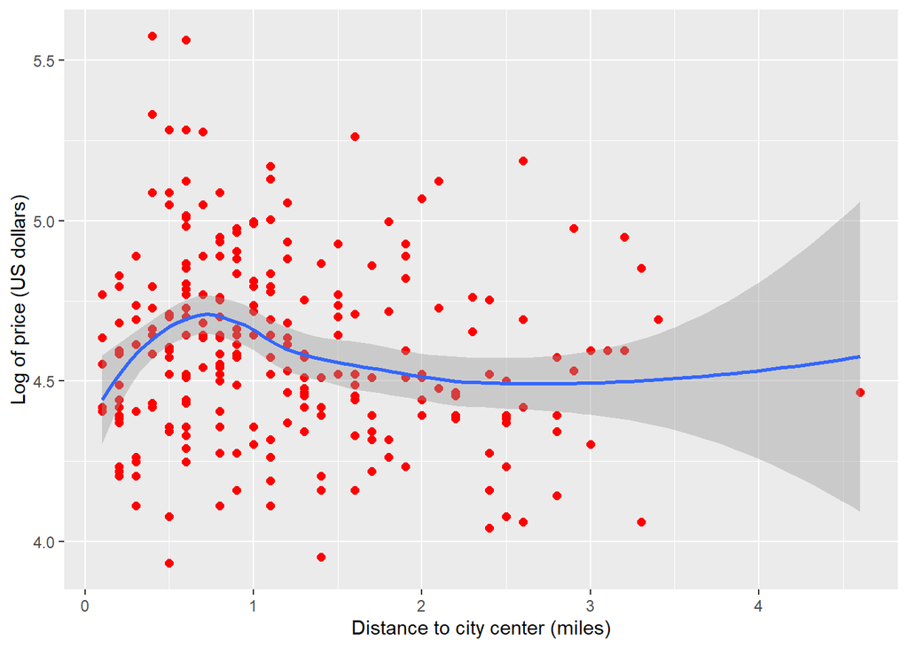

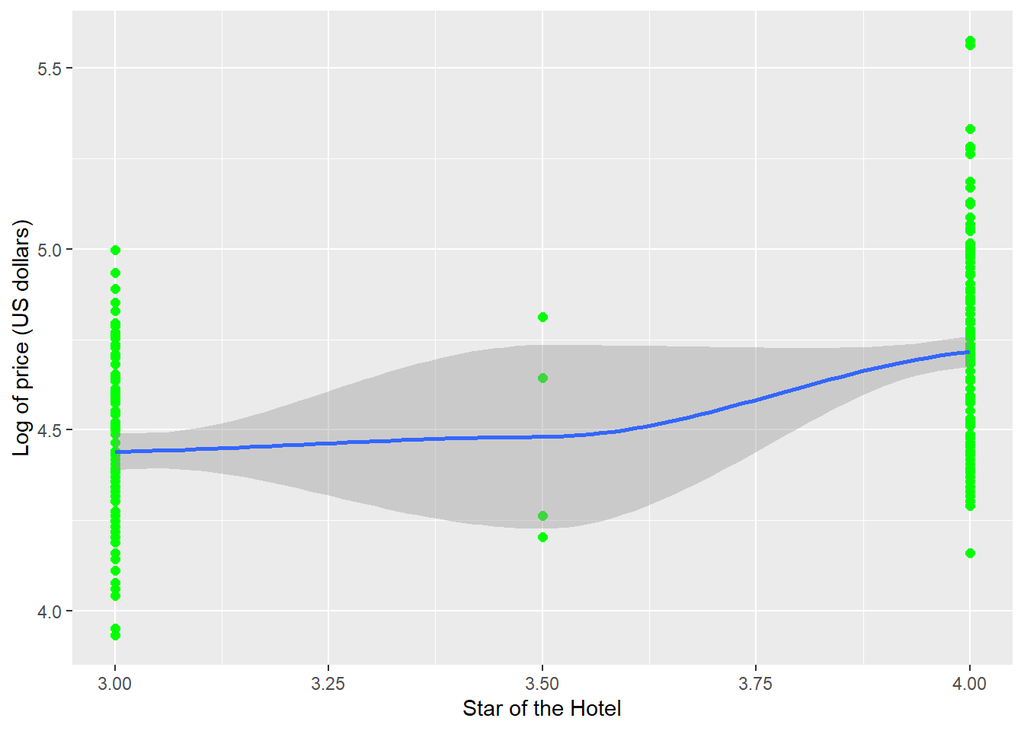

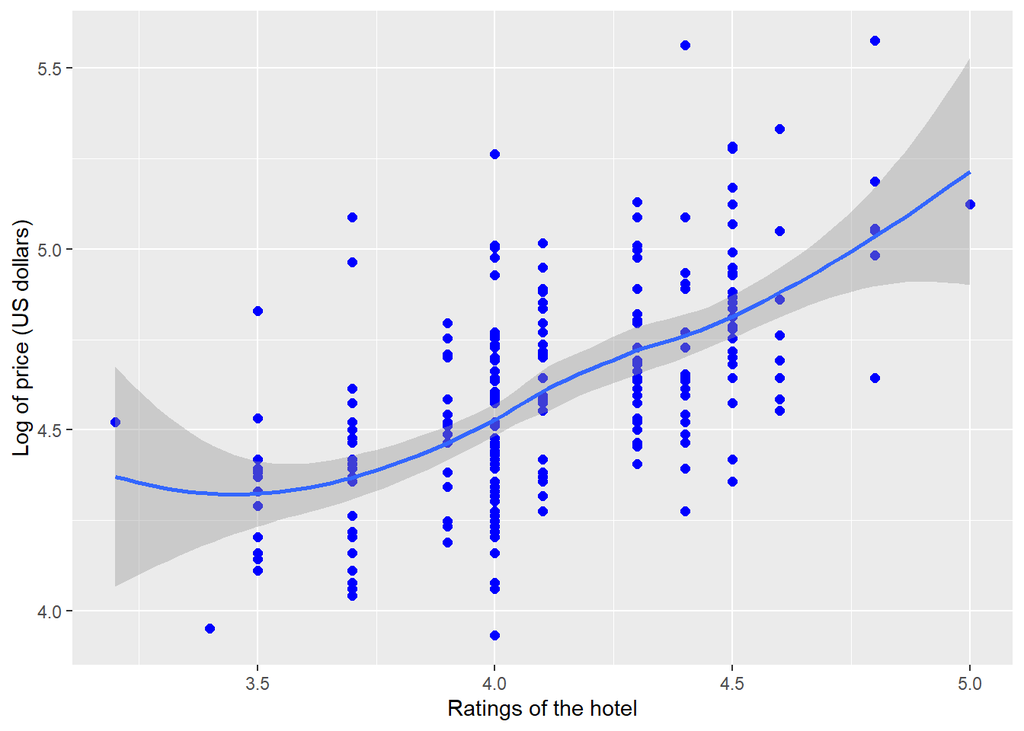

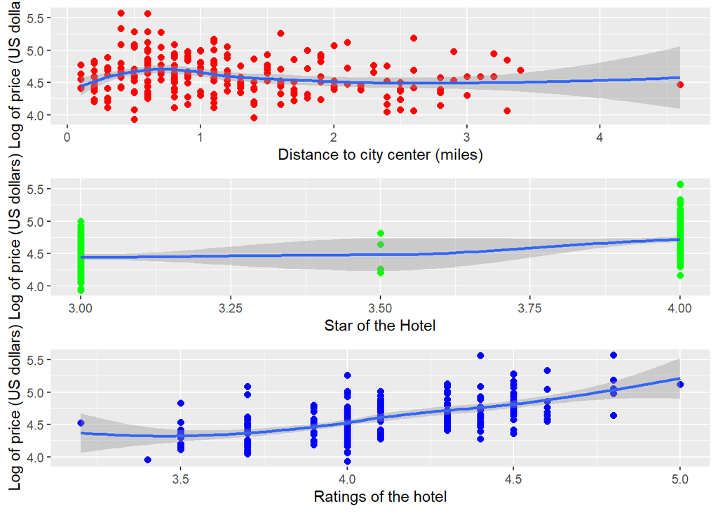

```
## OLS estimation, Dep. Var.: lnprice
## Observations: 248
## Standard-errors: Heteroskedasticity-robust
##             Estimate Std. Error t value  Pr(>|t|)
## (Intercept) 2.350811   0.203259 11.5656 < 2.2e-16 ***
## rating      0.548250   0.049573 11.0595 < 2.2e-16 ***
## ---
## Signif. codes:  0 '***' 0.001 '**' 0.01 '*' 0.05 '.' 0.1 ' ' 1
## RMSE: 0.232269   Adj. R2: 0.356083
```

```
## OLS estimation, Dep. Var.: lnprice
## Observations: 248
## Standard-errors: Heteroskedasticity-robust
##              Estimate Std. Error   t value  Pr(>|t|)
## (Intercept)  4.666467   0.034013 137.19775 < 2.2e-16 ***
## distance    -0.054502   0.022305  -2.44349   0.01525 *
## ---
## Signif. codes:  0 '***' 0.001 '**' 0.01 '*' 0.05 '.' 0.1 ' ' 1
## RMSE: 0.286633   Adj. R2: 0.019381
```

```
## OLS estimation, Dep. Var.: lnprice
## Observations: 248
## Standard-errors: Heteroskedasticity-robust
##              Estimate Std. Error  t value  Pr(>|t|)
## (Intercept)  2.425869   0.204779 11.84627 < 2.2e-16 ***
## distance    -0.032644   0.017848 -1.82896  0.068621 .
## rating       0.539538   0.049276 10.94926 < 2.2e-16 ***
## ---
## Signif. codes:  0 '***' 0.001 '**' 0.01 '*' 0.05 '.' 0.1 ' ' 1
## RMSE: 0.230764   Adj. R2: 0.361809
```

```
## OLS estimation, Dep. Var.: lnprice
## Observations: 248
## Standard-errors: Heteroskedasticity-robust
##                              Estimate Std. Error   t value   Pr(>|t|)
## (Intercept)                  5.812027   1.720373  3.378353 0.00084971 ***
## lspline(distance, c(1, 4))1 -0.068455   0.066197 -1.034113 0.30211585
## lspline(distance, c(1, 4))2 -0.018348   0.030573 -0.600152 0.54896655
## lspline(distance, c(1, 4))3 -0.021902   0.120264 -0.182115 0.85564498
## lspline(rating, 3.5)1       -0.425576   0.493554 -0.862268 0.38939366
## lspline(rating, 3.5)2        0.560074   0.051781 10.816244  < 2.2e-16 ***
## ---
## Signif. codes:  0 '***' 0.001 '**' 0.01 '*' 0.05 '.' 0.1 ' ' 1
## RMSE: 0.229826   Adj. R2: 0.359137
```

|  |  | reg0 | reg1 | reg2 |
| --- | --- | --- | --- | --- |
| 1 | Dependent Var.: | lnprice | lnprice | lnprice |
| 2 |  |  |  |  |
| 3 | Constant | 2.351*** (0.2033) | 4.666*** (0.0340) | 2.426*** (0.2048) |
| 4 | rating | 0.5482*** (0.0496) |  | 0.5395*** (0.0493) |
| 5 | distance |  | -0.0545* (0.0223) | -0.0326. (0.0179) |
| 6 | _______________ | __________________ | _________________ | __________________ |
| 7 | S.E. type | Heteroskedas.-rob. | Heteroskeda.-rob. | Heteroskedas.-rob. |
| 8 | Observations | 248 | 248 | 248 |
| 9 | R2 | 0.35869 | 0.02335 | 0.36698 |
| 10 | Adj. R2 | 0.35608 | 0.01938 | 0.36181 |

```
##
## =========================================================
##                        Model 1     Model 2     Model 3
## ---------------------------------------------------------
## (Intercept)              2.35 ***    4.67 ***    2.43 ***
##                         (0.20)      (0.03)      (0.20)
## rating                   0.55 ***                0.54 ***
##                         (0.05)                  (0.05)
## distance                            -0.05 *     -0.03
##                                     (0.02)      (0.02)
## ---------------------------------------------------------
## Num. obs.              248         248         248
## R^2 (full model)         0.36        0.02        0.37
## R^2 (proj model)
## Adj. R^2 (full model)    0.36        0.02        0.36
## Adj. R^2 (proj model)
## =========================================================
## *** p < 0.001; ** p < 0.01; * p < 0.05
```

# Interpretation

Models 1 and 3 are highly significant (Model 2 is significant at the 10% level but the intercept shows it is not quite as accurate as the other models). However, model 3 is the most accurate having two explanatory variables that affect lnprice therefore, it is the best.

| hotel_id | price | price_hat | lnprice | lnprice_hat | lnprice_resid | distance | stars | rating |
| --- | --- | --- | --- | --- | --- | --- | --- | --- |
| 1157 | 72 | 117.32745 | 4.276666 | 4.764969 | -0.4883026 | 0.9 | 3 | 4.4 |
| 1168 | 78 | 124.93850 | 4.356709 | 4.827822 | -0.4711128 | 0.8 | 3 | 4.5 |
| 1427 | 58 | 89.29031 | 4.060443 | 4.491893 | -0.4314499 | 3.3 | 3 | 4.0 |
| 1487 | 51 | 96.38216 | 3.931826 | 4.568321 | -0.6364955 | 0.5 | 3 | 4.0 |
| 1508 | 59 | 90.61062 | 4.077537 | 4.506571 | -0.4290340 | 2.5 | 3 | 4.0 |

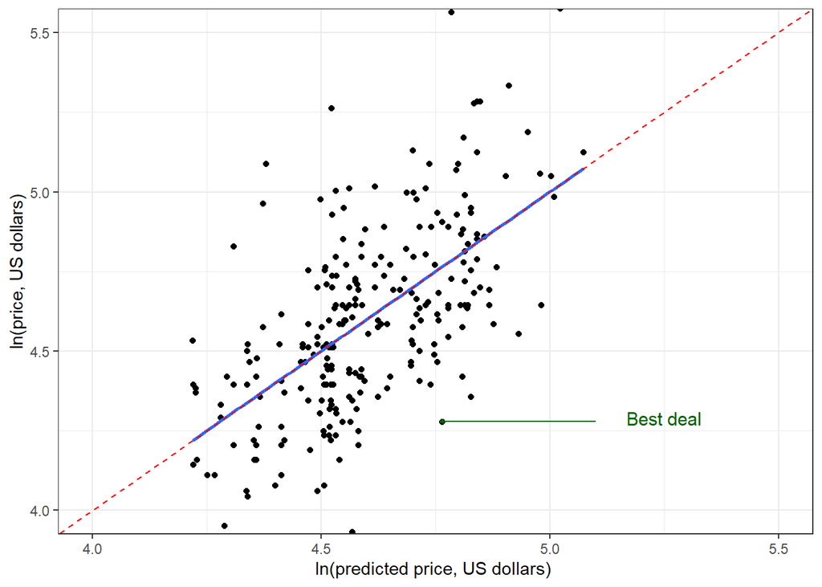

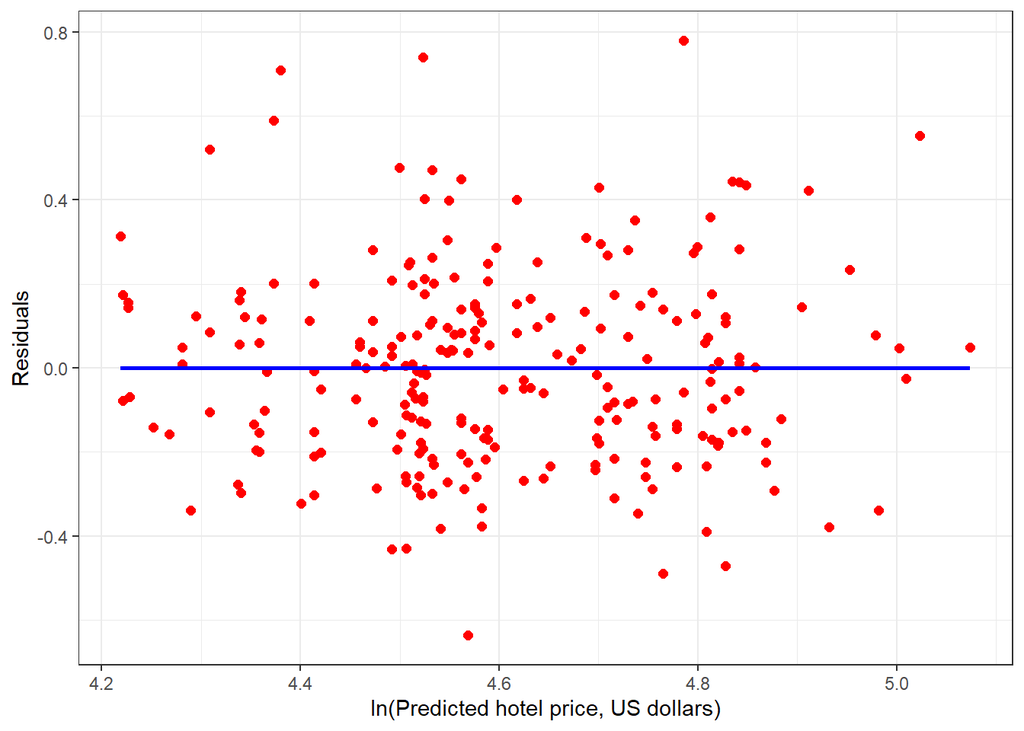

| fit | se.fit | ci_low | ci_high |
| --- | --- | --- | --- |
| 4.07078 | 0.04984088 | 3.972608 | 4.168951 |

|  | fit | se.fit | ci_low | ci_high | pred_price | PI_up | PI_low |
| --- | --- | --- | --- | --- | --- | --- | --- |
| 1 | 4.354207 | 0.1495318 | 3.809421 | 4.898993 | 77.80512 | 134.1546 | 45.12432 |

| PI_low | PI_up |
| --- | --- |
| 45.12432 | 134.1546 |

This price is good because at the 95% confidence interval, it gives a more accurate predicted value.We can compare this with other cities through RMSE analysis and compare the trend of the predicted value. I have incorporated the new data in the actual dataset. Then used the following process.

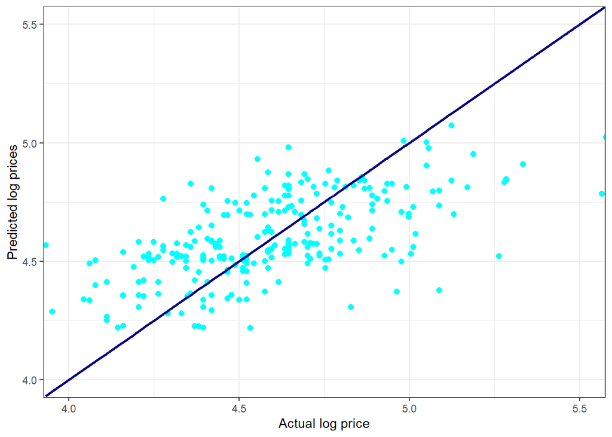

To visualize the whether the predicted trend best fit with the actual line.The new price is not an outlier.